# Machine Learning: AllLife Bank Personal Loan Campaign

#### Plot for CCAvg

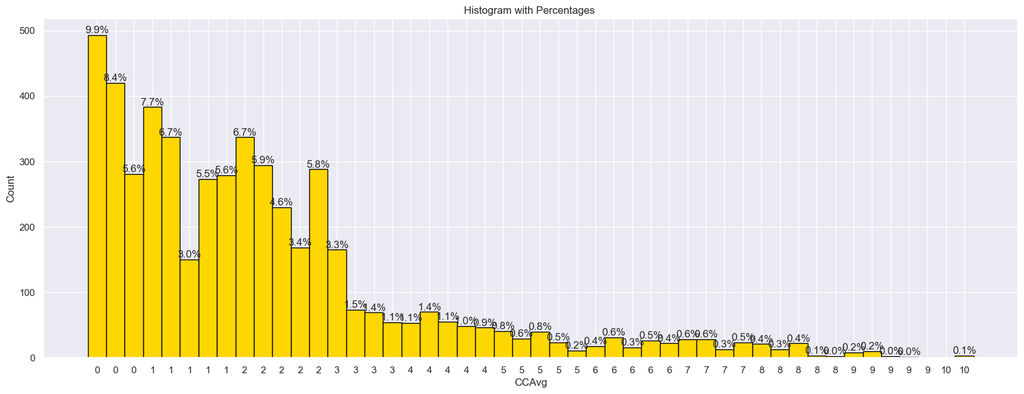

```python
HistLablPlot (df_new,'CCAvg')
```

#### Plot for Morgage biger than 0

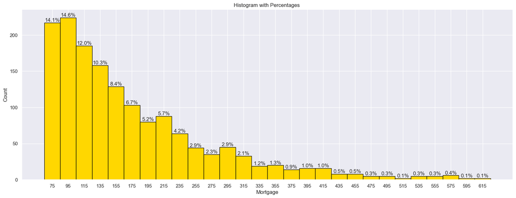

```python
HistLablPlot (df[df['Mortgage']>0],'Mortgage')
```

```python
# Bar plot for catigorical value
import seaborn as sns
import matplotlib.pyplot as plt

def BarPlot(data,feature):
# Sample categorical data
    categories = data[feature].unique()
    counts = df_new[feature].value_counts()

# Calculate the total count and the percentage of each category
    total = sum(counts)
    percentages = [100 * count / total for count in counts]

# Create the bar plot
    sns.barplot(x=categories, y=counts, color='greenyellow')

# Annotate each bar with the percentage
    for i, percentage in enumerate(percentages):
        plt.text(i, counts[i] / 2, f'{percentage:.1f}%', ha='center', va='center', color='black')

    plt.show()
```

#### Plot for Education

[figure not shown]

```python
BarPlot(df_new,"Education")
```

#### Plot for Personal_Loan

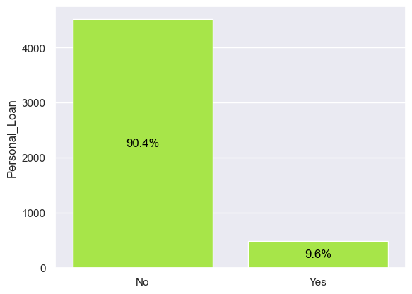

```python
BarPlot(df_new,"Personal_Loan")
```

#### Plot for Securities_Account

[figure not shown]

```python
BarPlot(df_new,"Securities_Account")
```

#### Plot for CD_Account

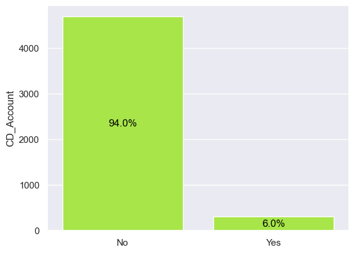

```python
BarPlot(df_new,"CD_Account")
```

#### Plot for Online

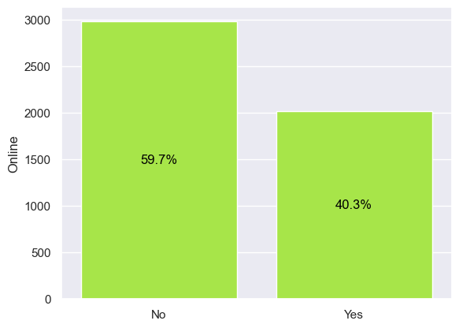

```python
BarPlot(df_new,"Online")
```

#### Plot for CreditCard

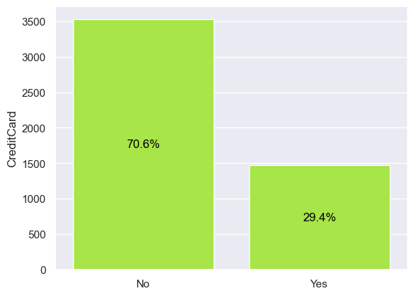

```python
BarPlot(df_new,"CreditCard")
```

```python
# No data null
df.isnull().sum()
```

```
ID                    0
Age                   0
Experience            0
Income                0
ZIPCode               0
Family                0
CCAvg                 0
Education             0
Mortgage              0
Personal_Loan         0
Securities_Account    0
CD_Account            0
Online                0
CreditCard            0
dtype: int64
```

### finding outlier

```python
# calcoulate Q1,Q2,Q3
numeric_column=['Age','Experience','Income','Family','CCAvg','Mortgage']
Q1=df_new[numeric_column].quantile(.25)
Q2=df_new[numeric_column].quantile(.50)
Q3=df_new[numeric_column].quantile(.75)
```

```python
# Calculating Outlier
df_n=df[numeric_column]
IQR=Q3-Q1
outliers = df_n[((df_n < (Q1 - 1.5 * IQR)) | (df_n > (Q3 + 1.5 * IQR)))]

# Sum of outlier for each numeric value
outliers.sum()
```

```
Age                0.0
Experience         0.0
Income         18688.0
Family             0.0
CCAvg           2217.8
Mortgage      103498.0
dtype: float64
```

```python
# Total number of  outlier
out1=outliers['Income'].value_counts().sum()
out2=outliers['CCAvg'].value_counts().sum()
out3=outliers['Mortgage'].value_counts().sum()

print ('Total number of  Income outlier',out1)
print ('Total number of  CCAvg outlier',out2)
print ('Total number of  Mortgage outlier',out3)
```

```
Total number of  Income outlier 96
Total number of  CCAvg outlier 324
Total number of  Mortgage outlier 291
```

### Data Preparation for Modeling

```python
df['Education']=df['Education'].replace({1:'Undergraduaate',2:'Graduate',3:'Advanced/Professional'})
```

```python
df['ZIPCode']=df['ZIPCode'].astype(str)
df['ZIPCode']=df['ZIPCode'].str[0:2]
```

```python
X=df.drop(['Personal_Loan','Experience','ID'],axis=1)
Y=df['Personal_Loan']
X=pd.get_dummies(X,columns=['Education','ZIPCode'],drop_first=True)

X_train,X_test,Y_train,Y_test=train_test_split(X,Y,test_size=.30,random_state=1)
```

```python
X_train.head()
```

|  | Age | Income | Family | CCAvg | Mortgage | Securities_Account | CD_Account | Online | CreditCard | Education_Graduate | Education_Undergraduaate | ZIPCode_91 | ZIPCode_92 | ZIPCode_93 | ZIPCode_94 | ZIPCode_95 | ZIPCode_96 |
| --- | --- | --- | --- | --- | --- | --- | --- | --- | --- | --- | --- | --- | --- | --- | --- | --- | --- |
| 1334 | 47 | 35 | 2 | 1.3 | 0 | 0 | 0 | 1 | 0 | 0 | 1 | 0 | 0 | 0 | 1 | 0 | 0 |
| 4768 | 38 | 39 | 1 | 2.0 | 0 | 0 | 0 | 1 | 0 | 1 | 0 | 0 | 0 | 1 | 0 | 0 | 0 |
| 65 | 59 | 131 | 1 | 3.8 | 0 | 0 | 0 | 1 | 1 | 0 | 1 | 1 | 0 | 0 | 0 | 0 | 0 |
| 177 | 29 | 65 | 4 | 1.8 | 244 | 0 | 0 | 0 | 0 | 1 | 0 | 0 | 0 | 0 | 1 | 0 | 0 |
| 4489 | 39 | 21 | 3 | 0.2 | 0 | 0 | 0 | 1 | 0 | 1 | 0 | 0 | 0 | 0 | 0 | 1 | 0 |

```python
print("Shape of Training set : ", X_train.shape)
print("Shape of test set : ", X_test.shape)
print("Percentage of classes in training set:")
print(Y_train.value_counts(normalize=True))
print("Percentage of classes in test set:")
print(Y_test.value_counts(normalize=True))
```

```
Shape of Training set :  (3500, 17)
Shape of test set :  (1500, 17)
Percentage of classes in training set:
0    0.905429
1    0.094571
Name: Personal_Loan, dtype: float64
Percentage of classes in test set:
0    0.900667
1    0.099333
Name: Personal_Loan, dtype: float64
```

## Model Building

### Model Evaluation Criterion

```python
model = DecisionTreeClassifier(criterion='gini',random_state=1)
```

```python
# Train the model
model.fit(X_train,Y_train)
```

```
DecisionTreeClassifier(random_state=1)
```

#### Checking model performance on training data

```python
# Evaluate Performance
def Evaluation (model,pridictor,target):

    Y_pred=model.predict(pridictor)

    accuracy=round(accuracy_score(target,Y_pred),3)

    recall=round(recall_score(target,Y_pred),3)

    precision=round(precision_score(target,Y_pred),3)

    f1=round(f1_score(target,Y_pred),3)

    eva={'f1=':f1,'accuracy=':accuracy,'recall=':recall,'precision=':precision}

    return eva
```

```python
Evaluation(model,X_train,Y_train)
```

```
{'f1=': 1.0, 'accuracy=': 1.0, 'recall=': 1.0, 'precision=': 1.0}
```

```python
# Confusion Matrix

def Plot_Confusion_Matrix (model,pridector,target):
    Y_pred=model.predict(pridector)
    cm=confusion_matrix(target,Y_pred)
    sns.heatmap(cm,annot=True,fmt="d")
    plt.ylabel("True label")
    plt.xlabel("Predicted label")

    print('Confusion Matrix %',cm)
```

```
Confusion Matrix % [[3169    0]
 [   0  331]]
```

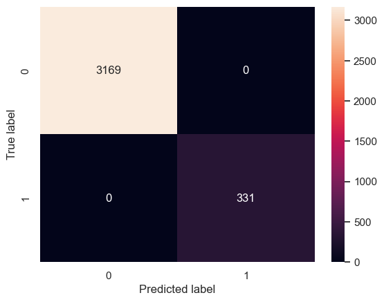

```python
Plot_Confusion_Matrix (model,X_train,Y_train)
```

### Visualizing the Decision Tree¶

```python
feature_names
```

```
['Age',
 'Income',
 'Family',
 'CCAvg',
 'Mortgage',
 'Securities_Account',
 'CD_Account',
 'Online',
 'CreditCard',
 'Education_Graduate',
 'Education_Undergraduaate',
 'ZIPCode_91',
 'ZIPCode_92',
 'ZIPCode_93',
 'ZIPCode_94',
 'ZIPCode_95',
 'ZIPCode_96']
```

```python
from sklearn.tree import export_text
feature_names = list(X_train.columns)
text_representation = export_text(model,feature_names=feature_names,show_weights=True)
print(text_representation)
```

```
|--- Income <= 116.50
|   |--- CCAvg <= 2.95
|   |   |--- Income <= 106.50
|   |   |   |--- weights: [2553.00, 0.00] class: 0
|   |   |--- Income >  106.50
|   |   |   |--- Family <= 3.50
|   |   |   |   |--- ZIPCode_93 <= 0.50
|   |   |   |   |   |--- Age <= 28.50
|   |   |   |   |   |   |--- Education_Undergraduaate <= 0.50
|   |   |   |   |   |   |   |--- weights: [0.00, 1.00] class: 1
|   |   |   |   |   |   |--- Education_Undergraduaate >  0.50
|   |   |   |   |   |   |   |--- weights: [5.00, 0.00] class: 0
|   |   |   |   |   |--- Age >  28.50
|   |   |   |   |   |   |--- CCAvg <= 2.20
|   |   |   |   |   |   |   |--- weights: [48.00, 0.00] class: 0
|   |   |   |   |   |   |--- CCAvg >  2.20
|   |   |   |   |   |   |   |--- Age <= 48.50
|   |   |   |   |   |   |   |   |--- Mortgage <= 204.00
|   |   |   |   |   |   |   |   |   |--- weights: [0.00, 1.00] class: 1
|   |   |   |   |   |   |   |   |--- Mortgage >  204.00
|   |   |   |   |   |   |   |   |   |--- weights: [1.00, 0.00] class: 0
|   |   |   |   |   |   |   |--- Age >  48.50
|   |   |   |   |   |   |   |   |--- weights: [6.00, 0.00] class: 0
|   |   |   |   |--- ZIPCode_93 >  0.50
|   |   |   |   |   |--- Income <= 112.00
|   |   |   |   |   |   |--- CCAvg <= 2.05
|   |   |   |   |   |   |   |--- weights: [0.00, 1.00] class: 1
|   |   |   |   |   |   |--- CCAvg >  2.05
|   |   |   |   |   |   |   |--- weights: [1.00, 0.00] class: 0
|   |   |   |   |   |--- Income >  112.00
|   |   |   |   |   |   |--- weights: [2.00, 0.00] class: 0
|   |   |   |--- Family >  3.50
|   |   |   |   |--- Age <= 32.50
|   |   |   |   |   |--- ZIPCode_92 <= 0.50
|   |   |   |   |   |   |--- weights: [12.00, 0.00] class: 0
|   |   |   |   |   |--- ZIPCode_92 >  0.50
|   |   |   |   |   |   |--- weights: [0.00, 1.00] class: 1
|   |   |   |   |--- Age >  32.50
|   |   |   |   |   |--- Age <= 60.00
|   |   |   |   |   |   |--- weights: [0.00, 6.00] class: 1
```

[output cut: 93 more lines]

```
|   |   |   |   |   |   |--- Age >  47.00
|   |   |   |   |   |   |   |--- weights: [1.00, 0.00] class: 0
|   |   |   |   |--- CD_Account >  0.50
|   |   |   |   |   |--- Income <= 93.50
|   |   |   |   |   |   |--- weights: [1.00, 0.00] class: 0
|   |   |   |   |   |--- Income >  93.50
|   |   |   |   |   |   |--- weights: [0.00, 5.00] class: 1
|--- Income >  116.50
|   |--- Education_Undergraduaate <= 0.50
|   |   |--- weights: [0.00, 222.00] class: 1
|   |--- Education_Undergraduaate >  0.50
|   |   |--- Family <= 2.50
|   |   |   |--- weights: [375.00, 0.00] class: 0
|   |   |--- Family >  2.50
|   |   |   |--- weights: [0.00, 47.00] class: 1
```

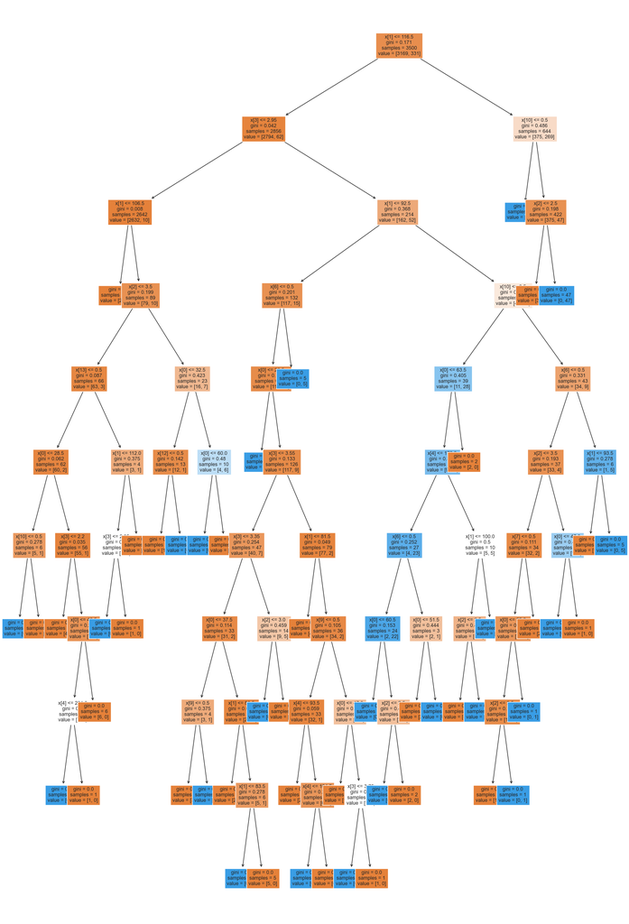

```python
from sklearn.tree import plot_tree
import matplotlib.pyplot as plt

plt.figure(figsize=(20,30))
plot_tree(model, filled=True,fontsize=9)
plt.show()
```

### Visualizatio of Decision Tree

```python
feature_names = X_train.columns.tolist()
print(feature_names)
```

```
['Age', 'Income', 'Family', 'CCAvg', 'Mortgage', 'Securities_Account', 'CD_Account', 'Online', 'CreditCard', 'Education_Graduate', 'Education_Undergraduaate', 'ZIPCode_91', 'ZIPCode_92', 'ZIPCode_93', 'ZIPCode_94', 'ZIPCode_95', 'ZIPCode_96']
```

```python
# importance of features in the tree building ( The importance of a feature is computed as the
# (normalized) total reduction of the criterion brought by that feature. It is also known as the Gini importance )

# Feature Importance
feature_importances=model.feature_importances_
for i, feature in enumerate(feature_names):
    print(f"Importance of {feature}: {feature_importances[i]:.4f}")
```

```
Importance of Age: 0.0334
Importance of Income: 0.3084
Importance of Family: 0.1674
Importance of CCAvg: 0.0459
Importance of Mortgage: 0.0079
Importance of Securities_Account: 0.0000
Importance of CD_Account: 0.0257
Importance of Online: 0.0006
Importance of CreditCard: 0.0000
Importance of Education_Graduate: 0.0033
Importance of Education_Undergraduaate: 0.4037
Importance of ZIPCode_91: 0.0000
Importance of ZIPCode_92: 0.0031
Importance of ZIPCode_93: 0.0006
Importance of ZIPCode_94: 0.0000
Importance of ZIPCode_95: 0.0000
Importance of ZIPCode_96: 0.0000
```

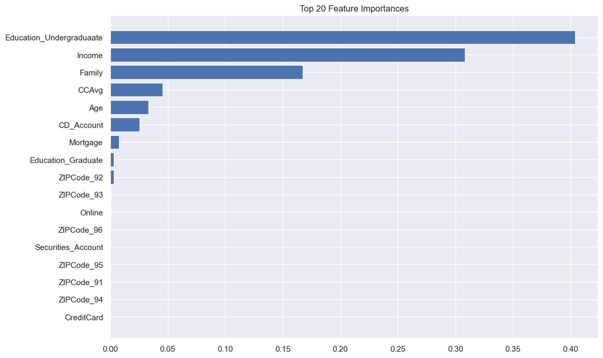

```python
import matplotlib.pyplot as plt
import numpy as np

# Assuming 'model' is your trained model
importances = model.feature_importances_



# Sort the feature importances in descending order and get the indices
indices = np.argsort(importances)[::-1]

# Decide how many features you want to display (e.g., top 20)
top_n = 17

# Select the indices of the top n features
top_indices = indices[:top_n]

# Create the plot
plt.figure(figsize=(12, 8))
plt.title('Top 20 Feature Importances')
plt.barh(range(top_n), importances[top_indices], color='b', align='center')
plt.yticks(range(top_n), np.array(feature_names)[top_indices])
plt.gca().invert_yaxis()  # Invert the y-axis to have the highest bar at the top
plt.show()
```

#### Checking model performance on test data

```python
Evaluation(model,X_test,Y_test)
```

```
{'f1=': 0.909, 'accuracy=': 0.982, 'recall=': 0.906, 'precision=': 0.912}
```

```
Confusion Matrix % [[1338   13]
 [  14  135]]
```

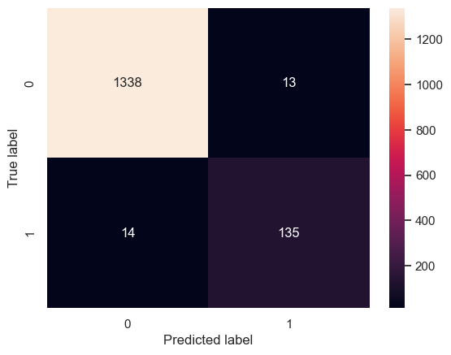

```python
Plot_Confusion_Matrix (model,X_test,Y_test)
```

### Model Performance Improvement

### Pre_Pruning

```python
# Hyperparameter Tuning. Use grid search or random search to find the best hyperparameters.
from sklearn.model_selection import GridSearchCV

paramiters={'max_depth':np.arange(6, 11),'min_samples_leaf':np.arange(5, 12),"max_leaf_nodes": np.arange(5, 12)}
# Run grid search
grid_search=GridSearchCV(estimator=model,scoring='recall',param_grid=paramiters,cv=5)
grid_search.fit(X_train,Y_train)

# Get the best parameters
best_params=grid_search.best_params_
# creat new model with best paramiters
best_model= DecisionTreeClassifier(**best_params,random_state=1)
# fit the model of the best parameters
best_model.fit(X_train,Y_train)
```

```
DecisionTreeClassifier(max_depth=6, max_leaf_nodes=8, min_samples_leaf=7,
                       random_state=1)
```

```python
# Cross-Validation to ensure the model’s stability.
from sklearn.model_selection import cross_val_score
scores=cross_val_score(model,X,Y,cv=5)
scores
```

```
array([0.981, 0.984, 0.982, 0.983, 0.977])
```

##### Checking performance on training data

```python
Evaluation (best_model,X_train,Y_train)
```

```
{'f1=': 0.934, 'accuracy=': 0.988, 'recall=': 0.915, 'precision=': 0.953}
```

```
Confusion Matrix % [[3154   15]
 [  28  303]]
```

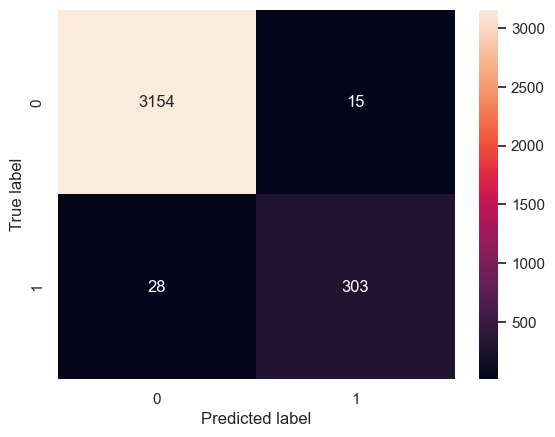

```python
Plot_Confusion_Matrix (best_model,X_train,Y_train)
```

##### Visualizing the Decision Tree

```python
feature_names = X_train.columns.tolist()
print(feature_names)
```

```
['Age', 'Income', 'Family', 'CCAvg', 'Mortgage', 'Securities_Account', 'CD_Account', 'Online', 'CreditCard', 'Education_Graduate', 'Education_Undergraduaate', 'ZIPCode_91', 'ZIPCode_92', 'ZIPCode_93', 'ZIPCode_94', 'ZIPCode_95', 'ZIPCode_96']
```

```python
# Feature Importance
feature_importances=best_model.feature_importances_
for i, feature in enumerate(feature_names):
    print(f"Importance of {feature}: {feature_importances[i]:.4f}")
```

```
Importance of Age: 0.0000
Importance of Income: 0.3347
Importance of Family: 0.1661
Importance of CCAvg: 0.0430
Importance of Mortgage: 0.0000
Importance of Securities_Account: 0.0000
Importance of CD_Account: 0.0000
Importance of Online: 0.0000
Importance of CreditCard: 0.0000
Importance of Education_Graduate: 0.0000
Importance of Education_Undergraduaate: 0.4562
Importance of ZIPCode_91: 0.0000
Importance of ZIPCode_92: 0.0000
Importance of ZIPCode_93: 0.0000
Importance of ZIPCode_94: 0.0000
Importance of ZIPCode_95: 0.0000
Importance of ZIPCode_96: 0.0000
```

```python
from sklearn.tree import export_text
feature_names = list(X_train.columns)
text_representation = export_text(best_model,feature_names=feature_names,show_weights=True)
print(text_representation)
```

```
|--- Income <= 116.50
|   |--- CCAvg <= 2.95
|   |   |--- weights: [2632.00, 10.00] class: 0
|   |--- CCAvg >  2.95
|   |   |--- Income <= 92.50
|   |   |   |--- weights: [117.00, 15.00] class: 0
|   |   |--- Income >  92.50
|   |   |   |--- Education_Undergraduaate <= 0.50
|   |   |   |   |--- weights: [11.00, 28.00] class: 1
|   |   |   |--- Education_Undergraduaate >  0.50
|   |   |   |   |--- Family <= 2.50
|   |   |   |   |   |--- weights: [30.00, 3.00] class: 0
|   |   |   |   |--- Family >  2.50
|   |   |   |   |   |--- weights: [4.00, 6.00] class: 1
|--- Income >  116.50
|   |--- Education_Undergraduaate <= 0.50
|   |   |--- weights: [0.00, 222.00] class: 1
|   |--- Education_Undergraduaate >  0.50
|   |   |--- Family <= 2.50
|   |   |   |--- weights: [375.00, 0.00] class: 0
|   |   |--- Family >  2.50
|   |   |   |--- weights: [0.00, 47.00] class: 1
```

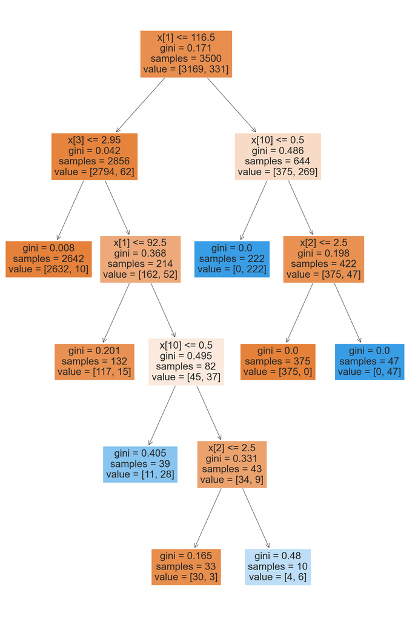

```python
from sklearn.tree import plot_tree
import matplotlib.pyplot as plt

plt.figure(figsize=(20,30))
plot_tree(best_model, filled=True)
plt.show()
```

[figure not shown]

```python
import matplotlib.pyplot as plt
import numpy as np


importances = best_model.feature_importances_



# Sort the feature importances in descending order and get the indices
indices = np.argsort(importances)[::-1]

# Decide how many features you want to display (e.g., top 17)
top_n = 17

# Select the indices of the top n features
top_indices = indices[:top_n]

# Create the plot
plt.figure(figsize=(12, 8))
plt.title('Top 17 Feature Importances')
plt.barh(range(top_n), importances[top_indices], color='b', align='center')
plt.yticks(range(top_n), np.array(feature_names)[top_indices])
plt.gca().invert_yaxis()  # Invert the y-axis to have the highest bar at the top
plt.show()
```

#### Checking performance on test data

```python
Evaluation (best_model,X_test,Y_test)
```

```
{'f1=': 0.891, 'accuracy=': 0.979, 'recall=': 0.852, 'precision=': 0.934}
```

```
Confusion Matrix % [[1342    9]
 [  22  127]]
```

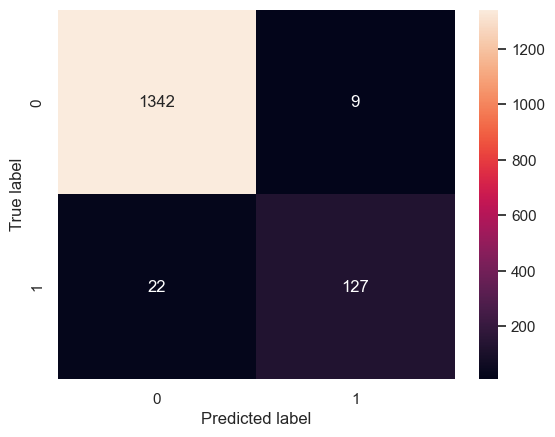

```python
Plot_Confusion_Matrix (best_model,X_test,Y_test)
```

#### Cost-Complexity Pruning¶

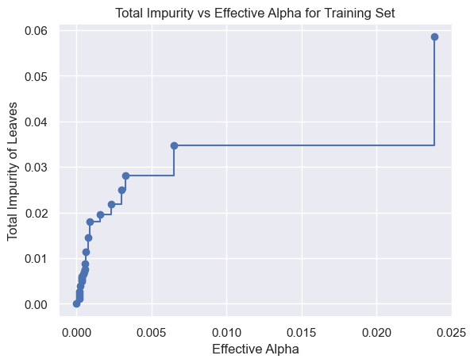

```
Number of nodes in the last tree is: 1 with ccp_alpha: 0.056364969335601575
```

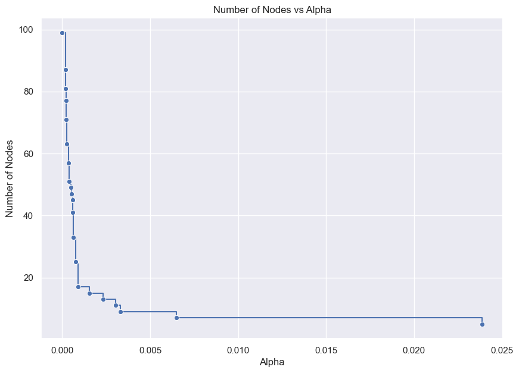

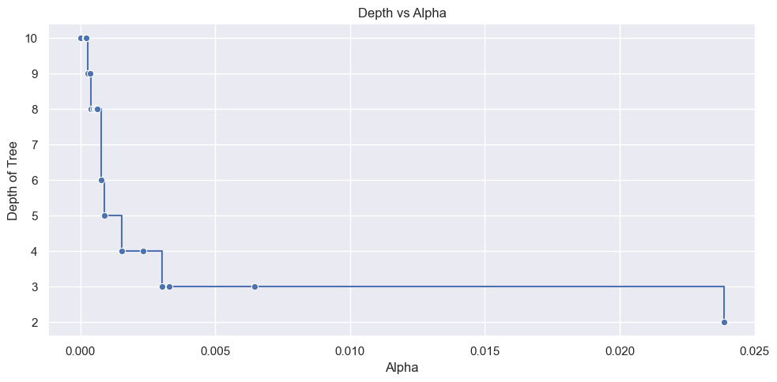

```
Accuracy after pruning: 0.98
```

```python
# Train a decision tree classifier without pruning
clf = DecisionTreeClassifier(random_state=0)
clf.fit(X_train, Y_train)

# Get the cost complexity pruning path
path = clf.cost_complexity_pruning_path(X_train, Y_train)
ccp_alphas, impurities = path.ccp_alphas, path.impurities

# Plot the total impurity of leaves vs effective alphas
fig, ax = plt.subplots()
ax.plot(ccp_alphas[:-1], impurities[:-1], marker='o', drawstyle='steps-post')
ax.set_xlabel('Effective Alpha')
ax.set_ylabel('Total Impurity of Leaves')
ax.set_title('Total Impurity vs Effective Alpha for Training Set')
plt.show()

# Train a series of decision trees with different alpha values
clfs = []
for ccp_alpha in ccp_alphas:
    clf = DecisionTreeClassifier(random_state=1, ccp_alpha=ccp_alpha)
    clf.fit(X_train, Y_train)
    clfs.append(clf)
print(
    "Number of nodes in the last tree is: {} with ccp_alpha: {}".format(
        clfs[-1].tree_.node_count, ccp_alphas[-1]
    )
)
# Remove the last element in clfs and ccp_alphas, because it is the trivial tree with only one node
clfs = clfs[:-1]
ccp_alphas = ccp_alphas[:-1]

# Plot Number of Nodes vs Alpha
node_counts = [clf.tree_.node_count for clf in clfs]
depth = [clf.tree_.max_depth for clf in clfs]
plt.figure(figsize=(10, 7))  # Create a new figure
sns.lineplot(x= ccp_alphas, y= node_counts, marker="o", drawstyle="steps-post")
plt.xlabel("Alpha")
plt.ylabel("Number of Nodes")
plt.title("Number of Nodes vs Alpha")  # Corrected from plt.settitle to plt.title

# Plot Depth vs Alpha
plt.figure(figsize=(10, 5))  # Create a new figure
sns.lineplot(x=ccp_alphas, y=depth, marker="o", drawstyle="steps-post")
plt.xlabel("Alpha")
plt.ylabel("Depth of Tree")
plt.title("Depth vs Alpha")  # Corrected from plt.set_title to plt.title

# Adjust layout to prevent overlapping
plt.tight_layout()

# Show plots
plt.show()
# Find the model with the best accuracy on the test data
best_accuracy = 0
best_clf = None
for clf in clfs:
    accuracy = clf.score(X_test, Y_test)
    if accuracy > best_accuracy:
        best_accuracy = accuracy
        best_clf = clf

# Model accuracy after pruning
accuracy_after_pruning = best_clf.score(X_test, Y_test)
print(f'Accuracy after pruning: {accuracy_after_pruning:.2f}')
```

```python
pd.DataFrame(path)
```

|  | ccp_alphas | impurities |
| --- | --- | --- |
| 0 | 0.000000 | 0.000000 |
| 1 | 0.000186 | 0.001114 |
| 2 | 0.000187 | 0.001675 |
| 3 | 0.000214 | 0.002104 |
| 4 | 0.000216 | 0.002750 |
| 5 | 0.000268 | 0.003824 |
| 6 | 0.000359 | 0.004900 |
| 7 | 0.000381 | 0.005280 |
| 8 | 0.000381 | 0.005661 |
| 9 | 0.000381 | 0.006042 |
| 10 | 0.000476 | 0.006519 |
| 11 | 0.000527 | 0.007046 |
| 12 | 0.000582 | 0.007628 |
| 13 | 0.000593 | 0.008813 |
| 14 | 0.000641 | 0.011379 |
| 15 | 0.000769 | 0.014456 |
| 16 | 0.000882 | 0.017985 |
| 17 | 0.001552 | 0.019536 |
| 18 | 0.002333 | 0.021869 |
| 19 | 0.003024 | 0.024893 |
| 20 | 0.003294 | 0.028187 |
| 21 | 0.006473 | 0.034659 |
| 22 | 0.023866 | 0.058525 |
| 23 | 0.056365 | 0.171255 |

#### Recall vs alpha for training and testing sets

```python
recall_train = []
for clf in clfs:
    pred_train = clf.predict(X_train)
    values_train = recall_score(Y_train, pred_train)
    recall_train.append(values_train)

recall_test = []
for clf in clfs:
    pred_test = clf.predict(X_test)
    values_test = recall_score(Y_test, pred_test)
    recall_test.append(values_test)
```

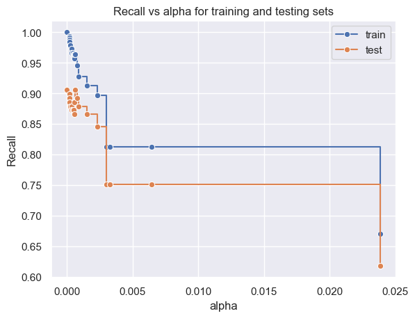

```python
#plt.subplots(1,1,figsize=(15, 5))
plt.xlabel("alpha")
plt.ylabel("Recall")
plt.title("Recall vs alpha for training and testing sets")
sns.lineplot(x=ccp_alphas, y=recall_train, marker="o", label="train", drawstyle="steps-post")
sns.lineplot(x=ccp_alphas, y=recall_test, marker="o", label="test", drawstyle="steps-post")

plt.show()
```

```python
index_cost_model = np.argmax(recall_test)
cost_model = clfs[index_cost_model]
print(cost_model)
```

```
DecisionTreeClassifier(random_state=1)
```

```python
estimator_2 = DecisionTreeClassifier(
    ccp_alpha=ccp_alpha, class_weight={0: 0.15, 1: 0.85}, random_state=1         ## Complete the code by adding the correct ccp_alpha value
)
estimator_2.fit(X_train, Y_train)
```

```
DecisionTreeClassifier(ccp_alpha=0.056364969335601575,
                       class_weight={0: 0.15, 1: 0.85}, random_state=1)
```

##### Checking performance on training data

```python
Evaluation (cost_model,X_train,Y_train)
```

```
{'f1=': 1.0, 'accuracy=': 1.0, 'recall=': 1.0, 'precision=': 1.0}
```

```
Confusion Matrix % [[3169    0]
 [   0  331]]
```

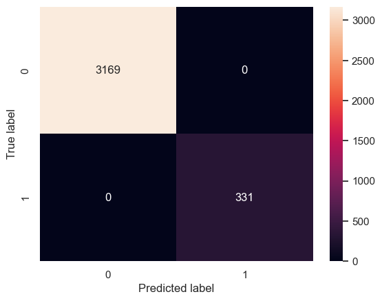

```python
Plot_Confusion_Matrix (cost_model,X_train,Y_train)
```

### Visualizing the Decision Tree

```python
from sklearn.tree import export_text
feature_names = list(X_train.columns)
text_representation = export_text(estimator_2,feature_names=feature_names,show_weights=True)
print(text_representation)
```

```
|--- Income <= 98.50
|   |--- weights: [392.70, 18.70] class: 0
|--- Income >  98.50
|   |--- Education_Undergraduaate <= 0.50
|   |   |--- weights: [13.35, 214.20] class: 1
|   |--- Education_Undergraduaate >  0.50
|   |   |--- Family <= 2.50
|   |   |   |--- weights: [67.65, 2.55] class: 0
|   |   |--- Family >  2.50
|   |   |   |--- weights: [1.65, 45.90] class: 1
```

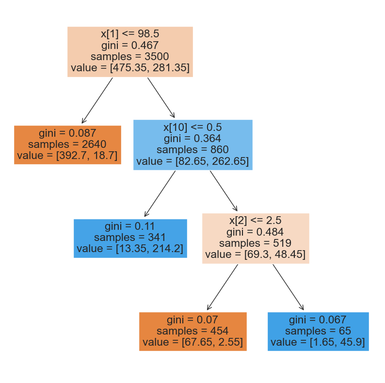

```python
from sklearn.tree import plot_tree
import matplotlib.pyplot as plt

plt.figure(figsize=(10,10))
plot_tree(estimator_2, filled=True)
plt.show()
```

```python
# Feature Importance
feature_importances = estimator_2.feature_importances_

# Create a list of tuples containing feature names and their importances
feature_importances_sorted = sorted(zip(feature_names, feature_importances), key=lambda x: x[1], reverse=True)

# Print feature importances in descending order
for feature, importance in feature_importances_sorted:
    print(f"Importance of {feature}: {importance:.4f}")
```

```
Importance of Income: 0.6749
Importance of Family: 0.1720
Importance of Education_Undergraduaate: 0.1531
Importance of Age: 0.0000
Importance of CCAvg: 0.0000
Importance of Mortgage: 0.0000
Importance of Securities_Account: 0.0000
Importance of CD_Account: 0.0000
Importance of Online: 0.0000
Importance of CreditCard: 0.0000
Importance of Education_Graduate: 0.0000
Importance of ZIPCode_91: 0.0000
Importance of ZIPCode_92: 0.0000
Importance of ZIPCode_93: 0.0000
Importance of ZIPCode_94: 0.0000
Importance of ZIPCode_95: 0.0000
Importance of ZIPCode_96: 0.0000
```

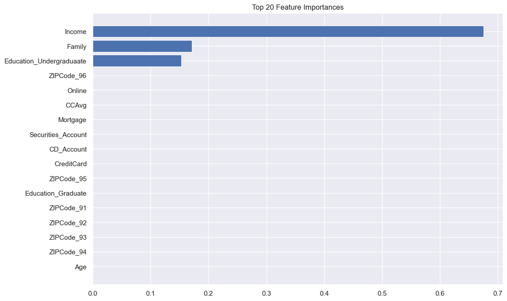

```python
# Assuming 'model' is your trained model
importances = estimator_2.feature_importances_



# Sort the feature importances in descending order and get the indices
indices = np.argsort(importances)[::-1]

# Decide how many features you want to display (e.g., top 20)
top_n = 17

# Select the indices of the top n features
top_indices = indices[:top_n]

# Create the plot
plt.figure(figsize=(12, 8))
plt.title('Top 20 Feature Importances')
plt.barh(range(top_n), importances[top_indices], color='b', align='center')
plt.yticks(range(top_n), np.array(feature_names)[top_indices])
plt.gca().invert_yaxis()  # Invert the y-axis to have the highest bar at the top
plt.show()
```

#### Checking performance on test data

```python
Evaluation (cost_model,X_test,Y_test)
```

```
{'f1=': 0.909, 'accuracy=': 0.982, 'recall=': 0.906, 'precision=': 0.912}
```

```
Confusion Matrix % [[1338   13]
 [  14  135]]
```

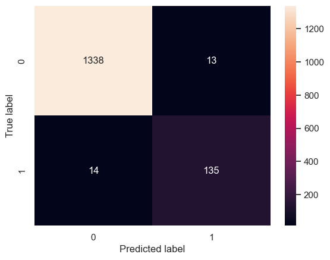

```python
Plot_Confusion_Matrix (cost_model,X_test,Y_test)
```

## Model Comparison and Final Model Selection

```python
 #Given dictionaries
dict1 = Evaluation (model,X_train,Y_train)
dict2 = Evaluation (best_model,X_train,Y_train)

# Convert dictionaries to DataFrame
compaire = pd.DataFrame([dict1, dict2])

# Rename index values
compaire.rename(index={0: 'Sklearn', 1: 'Pre Purning'}, inplace=True)

# Print the DataFrame
print("Comparing  on Train")
print(compaire)
```

```
Comparing  on Train
               f1=  accuracy=  recall=  precision=
Sklearn      1.000      1.000    1.000       1.000
Pre Purning  0.934      0.988    0.915       0.953
```

```python
#Given dictionaries
dict1 = Evaluation (model,X_test,Y_test)
dict2 = Evaluation (best_model,X_test,Y_test)

# Convert dictionaries to DataFrame
compaire = pd.DataFrame([dict1, dict2])

# Rename index values
compaire.rename(index={0: 'Sklearn', 1: 'Pre Purning'}, inplace=True)
print("Comparing  on Test")
# Print the DataFrame
print(df)
```

[output not shown]

## Actionable Insights and Business Recommendations

Summary of data

1- 5000 rows and 14 columns

2- df_dtypes: float64(1), int64(13)before modifing

3- No Null Number

4- 3462 People has No mortgage

5- 347 Number unique mortgage

6- 1470 customers have credit cards

7- 4520 number of how did not have loan . 90.4%

8- 480 number of how did have loan

9- education:

10- Personal_Loan Education

```
 No             Undergraduate           2003

                Advanced/Professional    1296

                Graduate                 1221

 Yes            Advanced/Professional     205

                Graduate                  182

                Undergraduate             93
```

11- 522 customer have securities account with the bank

12- 302 customer have a certificate of deposit (CD) account with the Bank

14-522 customer have securities account with the bank

15-personal Loan four most corr :

```
   Income                0.430739

   CD_Account            0.316355

   CCAvg                 0.313957

   Education             0.139492
```

16- plot

```
  'CCAvg','Personal_Loan = Yes'=>Right skew

  'CCAvg','Personal_Loan = No'=> Right skew
```

17

```
   'Income','Personal_Loan = Yes'=>Left skew

   'Income','Personal_Loan = No'=> Right skew
```

18 'Mortgage','Personal_Loan = Yes'=>Right skew

```
   'Mortgage','Personal_Loan = No'=> Right skew
```

19- histplot for Income, Mortgage and CCAvg has right skew

20-

• Age: Average age of customers is 45 years

• Experience: Tne median experience of customers is 20 years

• Income: Average income of customers is $73k

• CCAvg: Customers have average $1.93 in month.

• Mortgage: Average mortgage is $56k

• Family: Family average is 2.4

21- Outlier

```
Total number of  Income outlier 96

Total number of  CCAvg outlier 324

Total number of  Mortgage outlier 291
```

### What recommedations would you suggest to the bank?

- Bank has to work on costumer base on Income, Family, Education.
- personal Loan most four corr : Income 0.430739 ,CD_Account 0.316355 ,CCAvg 0.313957, Education 0.139492
- customer high income ,more family and advace education more lakily get loan
- customer who has more family has more chance to get loan
- We creat 3 model to work on data set
- Bank should work on customer who has more family and more income
- Customers who have a CD_Account most lakily nedd a Personal Loan
- Undergraduate custory they are not interested to get loan